# STA 141A: Assignment 3

Ishita Dutta, 918193342

**Instructions** You may adapt the code in the course materials or any sources (e.g., the Internet, classmates, friends). In fact, you can craft solutions for almost all questions from the course materials with minor modifications. However, you need to write up your own solutions and acknowledge all sources that you have cited in the Acknowledgement section.

Failing to acknowledge any non-original efforts will be counted as plagiarism. This incidence will be reported to the Student Judicial Affairs.

$(1)$ We will revisit the `nycflights13` data set. Extract the entries in February from the `flights` and `weather` dataset using `filter()` and `%>%`. Join the two extracted data sets together by `origin` and `time_hour`. You may want to use the `inner_join()` function for joining the data sets.

$Solution 1:$

```r
library(nycflights13)
library(tidyverse)
febflight = flights %>%
  filter(month == 2) %>%
  filter(is.na(arr_delay)!=TRUE)
febweather = weather %>%
  filter(month == 2)
d1 = inner_join(febflight, febweather, by=c('origin', 'time_hour')) #by only origin and time_hour
head(d1)
```

```
## # A tibble: 6 × 32
##   year.x month.x day.x dep_time sched_dep_time dep_delay arr_time sched_arr_time
##    <int>   <int> <int>    <int>          <int>     <dbl>    <int>          <int>
## 1   2013       2     1      456            500        -4      652            648
## 2   2013       2     1      520            525        -5      816            820
## 3   2013       2     1      527            530        -3      837            829
## 4   2013       2     1      532            540        -8     1007           1017
## 5   2013       2     1      540            540         0      859            850
## 6   2013       2     1      552            600        -8      714            715
## # … with 24 more variables: arr_delay <dbl>, carrier <chr>, flight <int>,
## #   tailnum <chr>, origin <chr>, dest <chr>, air_time <dbl>, distance <dbl>,
## #   hour.x <dbl>, minute <dbl>, time_hour <dttm>, year.y <int>, month.y <int>,
## #   day.y <int>, hour.y <int>, temp <dbl>, dewp <dbl>, humid <dbl>,
## #   wind_dir <dbl>, wind_speed <dbl>, wind_gust <dbl>, precip <dbl>,
## #   pressure <dbl>, visib <dbl>
```

$(2)$ Create a scatter plot of arrival delay versus precipitation using the data set obtained in Part 1. Explain your findings.

$Solution 2:$

[figure not shown]

```r
ggplot(d1, aes(x =  precip, y = arr_delay))  + geom_point(color = "light blue") + ggtitle("Arrival Delay vs Precipitation") + xlab("Arrival Delay") + ylab("Precipitation")
```

$(3)$ Create a polynomial expansion of the `precip` variable to the 15th degree using `poly()` function.

$Solution 3:$

```r
polyexpprecip = poly(d1$precip, degree = 15, raw = F)
polyexpprecip[1:3, 1:4]
```

```
##                1           2             3            4
## [1,] -0.00149917 0.001015952 -0.0007137704 0.0004527782
## [2,] -0.00149917 0.001015952 -0.0007137704 0.0004527782
## [3,] -0.00149917 0.001015952 -0.0007137704 0.0004527782
```

$(4)$ Consider arrival delay as the outcome and the polynomial terms obtained in Part (3) as the covariates. Build a prediction model using linear regression with lasso. Select the tuning parameter using cross-validation. You may want to use the `cv.glmnet` function in `glmnet`. Report the fitted model.

$Solution 4:$

```r
library(glmnet)
```

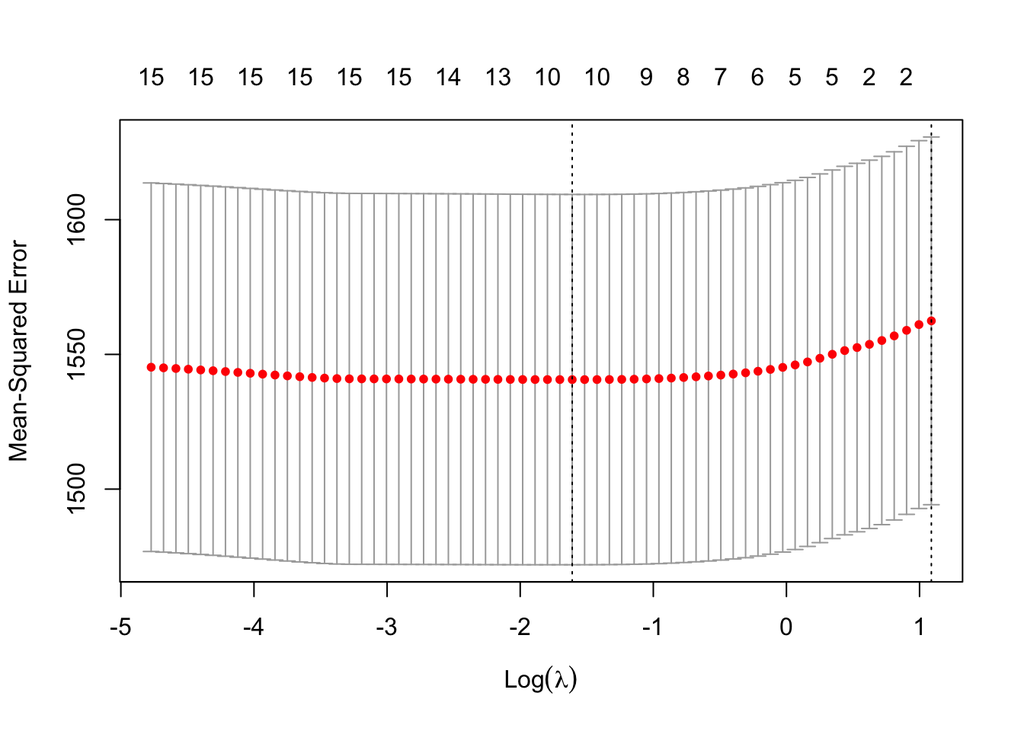

```r
model1 <- cv.glmnet(x=polyexpprecip, y = d1$arr_delay)
plot(model1)
```

$(5)$ Consider the `iris` data. Extract the data corresponding to the flower types *versicolor* and *virginica*, numbering a total of $100$ flowers. Set aside the first $10$ observations for each flower type as test data and use the remaining data consisting of 80 observations (with flower types as class labels) as training data.

$Solution 5:$

```r
library(tidyverse)
library(caret)
library(MASS)
d2 <- iris %>% filter(Species %in% c('versicolor', 'virginica'))
dindex = c(1:10, 51:60)
test_data = d2[dindex, ]
train_data = d2[-dindex, ]
```

$(6)$ Use *Linear Discriminant Analysis (LDA)* for classifying the test data. Use Sepal.Length and Sepal.Width as the predictor variables (or features). You may want to use the function `lda()`. a. Report the class-specific means of the predictor variables for the training data. b. Compute the *confusion matrix* for the test data, and the misclassification error rate.

$Solution 6:$

```r
lda(Species ~ ., data = test_data)
```

```
## Call:
## lda(Species ~ ., data = test_data)
##
## Prior probabilities of groups:
## versicolor  virginica
##        0.5        0.5
##
## Group means:
##            Sepal.Length Sepal.Width Petal.Length Petal.Width
## versicolor         6.10        2.87         4.37        1.38
## virginica          6.57        2.94         5.77        2.04
##
## Coefficients of linear discriminants:
##                    LD1
## Sepal.Length -2.167935
## Sepal.Width  -2.864190
## Petal.Length  4.000310
## Petal.Width   3.077102
```

```r
#confusionMatrix(iris, test_data)
```

$(7)$ Fit a logistic regression model to the training data, using the variables Sepal.Length and Sepal.Width as predictors. You may want to use `glm()` with argument `family = "binomial"`. a. Obtain the estimates and their standard errors for the model parameters. b. Compute the *confusion matrix* for the test data, and the misclassification error rate. c. Are both the predictor variables necessary for the purpose of classification? Justify.

$Solution 7:$

```r
train_data$Sdummy = train_data$Species =="versicolor"
test_data$Sdummy = test_data$Species =="versicolor"

model1 <- glm(Species ~ Sepal.Length + Sepal.Width, family = "binomial", data = train_data)
summary(model1)
```

```
##
## Call:
## glm(formula = Species ~ Sepal.Length + Sepal.Width, family = "binomial",
##     data = train_data)
##
## Deviance Residuals:
##      Min        1Q    Median        3Q       Max
## -1.82836  -0.74419  -0.05069   0.84764   1.88719
##
## Coefficients:
##              Estimate Std. Error z value Pr(>|z|)
## (Intercept)  -18.1620     4.3571  -4.168 3.07e-05 ***
## Sepal.Length   2.5495     0.7097   3.592 0.000328 ***
## Sepal.Width    0.8173     1.0109   0.809 0.418801
## ---
## Signif. codes:  0 '***' 0.001 '**' 0.01 '*' 0.05 '.' 0.1 ' ' 1
##
## (Dispersion parameter for binomial family taken to be 1)
##
##     Null deviance: 110.904  on 79  degrees of freedom
## Residual deviance:  79.924  on 77  degrees of freedom
## AIC: 85.924
##
## Number of Fisher Scoring iterations: 5
```

```r
x = exp(predict.glm(model1, newdata = test_data))
pred = x/(1+x)

observed = as.factor(as.numeric(test_data$Sdummy))
predval = as.factor(as.numeric(pred > 0.5))

confusionMatrix(data = predval, reference = observed)
```

```
## Confusion Matrix and Statistics
##
##           Reference
## Prediction 0 1
##          0 2 4
##          1 8 6
##
##                Accuracy : 0.4
##                  95% CI : (0.1912, 0.6395)
##     No Information Rate : 0.5
##     P-Value [Acc > NIR] : 0.8684
##
##                   Kappa : -0.2
##
##  Mcnemar's Test P-Value : 0.3865
##
##             Sensitivity : 0.2000
##             Specificity : 0.6000
##          Pos Pred Value : 0.3333
##          Neg Pred Value : 0.4286
##              Prevalence : 0.5000
##          Detection Rate : 0.1000
##    Detection Prevalence : 0.3000
##       Balanced Accuracy : 0.4000
##
##        'Positive' Class : 0
##
```

$(8)$ Fit a logistic regression model to the training data, using the variable Sepal.Length as the only predictor. a. Obtain the estimates and their standard errors for the model parameters. b. Compute the *confusion matrix* for the test data, and the misclassification error rate. c. Compare the results with those in Question 7. Does your result in 8.b support the answer to 7.c?

$Solution 8:$

```r
model2 <- glm(Species ~ Sepal.Length, family = "binomial", data = train_data)
summary(model2)
```

```
##
## Call:
## glm(formula = Species ~ Sepal.Length, family = "binomial", data = train_data)
##
## Deviance Residuals:
##      Min        1Q    Median        3Q       Max
## -1.90856  -0.77513  -0.06474   0.88167   1.92088
##
## Coefficients:
##              Estimate Std. Error z value Pr(>|z|)
## (Intercept)  -17.1552     4.1251  -4.159 3.20e-05 ***
## Sepal.Length   2.7647     0.6668   4.146 3.38e-05 ***
## ---
## Signif. codes:  0 '***' 0.001 '**' 0.01 '*' 0.05 '.' 0.1 ' ' 1
##
## (Dispersion parameter for binomial family taken to be 1)
##
##     Null deviance: 110.90  on 79  degrees of freedom
## Residual deviance:  80.59  on 78  degrees of freedom
## AIC: 84.59
##
## Number of Fisher Scoring iterations: 5
```

```r
x2 = exp(predict.glm(model2, newdata = test_data))
pred2 = x2/(1+x2)

observed2 = as.factor(as.numeric(test_data$Sdummy))
predval2 = as.factor(as.numeric(pred2 > 0.5))

confusionMatrix(data = predval2, reference = observed2)
```

```
## Confusion Matrix and Statistics
##
##           Reference
## Prediction 0 1
##          0 2 4
##          1 8 6
##
##                Accuracy : 0.4
##                  95% CI : (0.1912, 0.6395)
##     No Information Rate : 0.5
##     P-Value [Acc > NIR] : 0.8684
##
##                   Kappa : -0.2
##
##  Mcnemar's Test P-Value : 0.3865
##
##             Sensitivity : 0.2000
##             Specificity : 0.6000
##          Pos Pred Value : 0.3333
##          Neg Pred Value : 0.4286
##              Prevalence : 0.5000
##          Detection Rate : 0.1000
##    Detection Prevalence : 0.3000
##       Balanced Accuracy : 0.4000
##
##        'Positive' Class : 0
##
```

$(9)$ Use the *k Nearest Neighbors (kNN)* classification method to classify the test data, using only Sepal.Length as the predictor variable. Perform this analysis using $k=1$ and $k=5$. In each case, compute the *confusion matrix* for the test data, and the misclassification error rate. You may want to use the `knn()` function.

$Solution 9:$

```r
#I could not figure this one out, but this is what I had for code...
library(class)
model3= knn(train_data, test_data, cl = train_data$Species_dummy, k = 5)

x3 = exp(predict.knn(model3, newdata = test_data))
pred3 = x3/(1+x3)

observed3 = as.factor(as.numeric(test_data$Sdummy))
predval3 = as.factor(as.numeric(pred3 > 0.5))

confusionMatrix(data = predval3, reference = observed3)
```

[output not shown]

$(10)$ Write a very brief summary (maximum of 200 words) about the comparative performance of the three different classification methods for this data set.

## Acknowledgement

Discussed questions 2 and 7 with Li Zijian.